# Homework 5

Alisha Gumber

11/11/2019

## Homework

1. Attempt a regression tree-based method (not covered in this tutorial) on a reasonable dataset of your choice. Explain the results.

The difference between regression and classification is the output of the response variable. The output variable in regression is continous (numerical), and the output variable of classification is categorical (discrete). In general, tree-based methods are great for classification, but they can be trickier for regression models. I’m using the Pima Indian Diabetes dataset from the mlbench package to predict number of pregnancies. I’m using the rpart function for my regression tree, which is part of the rpart package. Rpart stands for ‘recursive partitioning’ for regression trees.

```r
data("PimaIndiansDiabetes")
#str(PimaIndiansDiabetes)

# set seed to make results reproducible
set.seed(29)

# split data into train and test subset
train_size <- floor(0.75 * nrow(PimaIndiansDiabetes))
train_pos <- sample(seq_len(nrow(PimaIndiansDiabetes)), size = train_size)

train_class <- PimaIndiansDiabetes[train_pos, ]
test_class <- PimaIndiansDiabetes[-train_pos, ]

# Train model using rpart. Need to set method to 'anova' for regression trees. If method is not chosen, by default, rpart will try to make the best guess as to which method to use.
fit <- rpart(pregnant ~ ., method="anova", data=train_class)

printcp(fit) # display the results - tells us variables used in construction of tree, root node error, and n.
```

```
##
## Regression tree:
## rpart(formula = pregnant ~ ., data = train_class, method = "anova")
##
## Variables actually used in tree construction:
## [1] age      glucose  insulin  pedigree triceps
##
## Root node error: 6543.9/576 = 11.361
##
## n= 576
##
##         CP nsplit rel error  xerror     xstd
## 1 0.345936      0   1.00000 1.00446 0.062805
## 2 0.030158      1   0.65406 0.67332 0.047262
## 3 0.019771      2   0.62391 0.63942 0.045663
## 4 0.014892      4   0.58436 0.64486 0.045812
## 5 0.011378      6   0.55458 0.67121 0.046464
## 6 0.011054      8   0.53182 0.70798 0.048698
## 7 0.010194      9   0.52077 0.71298 0.049041
## 8 0.010000     10   0.51057 0.71315 0.049034
```

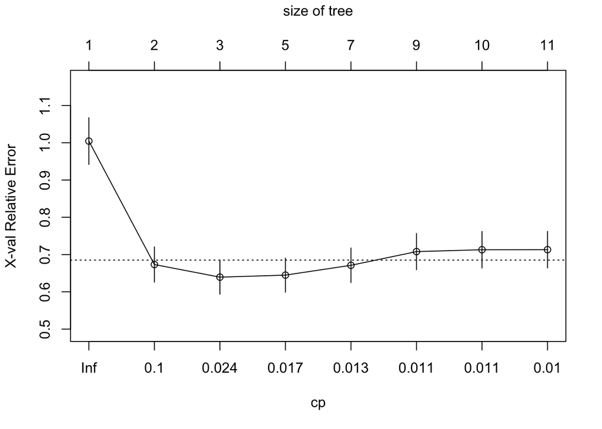

```r
plotcp(fit) # visualize cross-validation results
```

```r
summary(fit) # detailed summary of splits
```

```
## Call:
## rpart(formula = pregnant ~ ., data = train_class, method = "anova")
##   n= 576
##
##           CP nsplit rel error    xerror       xstd
## 1 0.34593630      0 1.0000000 1.0044613 0.06280486
## 2 0.03015825      1 0.6540637 0.6733209 0.04726196
## 3 0.01977058      2 0.6239054 0.6394229 0.04566274
## 4 0.01489220      4 0.5843643 0.6448602 0.04581209
## 5 0.01137844      6 0.5545799 0.6712104 0.04646354
## 6 0.01105434      8 0.5318230 0.7079752 0.04869818
## 7 0.01019373      9 0.5207687 0.7129766 0.04904143
## 8 0.01000000     10 0.5105749 0.7131495 0.04903419
##
## Variable importance
##      age  triceps diabetes  glucose pressure  insulin pedigree     mass
##       56        9        9        8        8        7        2        1
##
## Node number 1: 576 observations,    complexity param=0.3459363
##   mean=3.817708, MSE=11.36087
##   left son=2 (330 obs) right son=3 (246 obs)
##   Primary splits:
##       age      < 31.5   to the left,  improve=0.34593630, (0 missing)
##       diabetes splits as  LR,         improve=0.05784759, (0 missing)
##       pressure < 69     to the left,  improve=0.05313256, (0 missing)
##       insulin  < 7      to the right, improve=0.03572254, (0 missing)
##       triceps  < 7.5    to the right, improve=0.03542149, (0 missing)
##   Surrogate splits:
##       diabetes splits as  LR,         agree=0.656, adj=0.195, (0 split)
##       pressure < 77     to the left,  agree=0.644, adj=0.167, (0 split)
##       glucose  < 131.5  to the left,  agree=0.632, adj=0.138, (0 split)
##       triceps  < 7.5    to the right, agree=0.625, adj=0.122, (0 split)
##       insulin  < 7      to the right, agree=0.604, adj=0.073, (0 split)
##
## Node number 2: 330 observations,    complexity param=0.03015825
##   mean=2.106061, MSE=3.603903
##   left son=4 (225 obs) right son=5 (105 obs)
##   Primary splits:
##       age      < 26.5   to the left,  improve=0.16594080, (0 missing)
##       triceps  < 4      to the right, improve=0.07692640, (0 missing)
```

[output cut: 137 more lines]

```
##       diabetes splits as  LR,         improve=0.10953000, (0 missing)
##       mass     < 39.7   to the left,  improve=0.08418194, (0 missing)
##       pedigree < 0.4725 to the left,  improve=0.06105584, (0 missing)
##   Surrogate splits:
##       glucose  < 89.5   to the left,  agree=0.673, adj=0.273, (0 split)
##       pressure < 71     to the left,  agree=0.653, adj=0.227, (0 split)
##       diabetes splits as  LR,         agree=0.653, adj=0.227, (0 split)
##       triceps  < 33.5   to the right, agree=0.633, adj=0.182, (0 split)
##       insulin  < 14.5   to the left,  agree=0.592, adj=0.091, (0 split)
##
## Node number 254: 22 observations
##   mean=7.363636, MSE=5.867769
##
## Node number 255: 27 observations
##   mean=10, MSE=9.925926
```

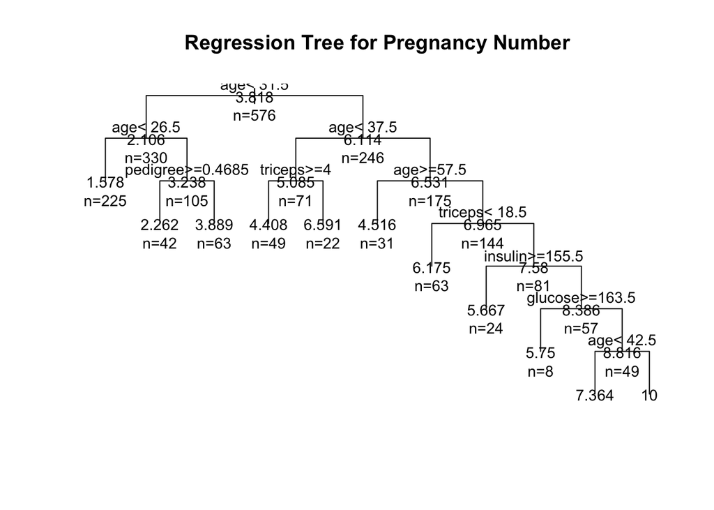

```r
# plot tree
plot(fit, uniform=TRUE,
   main="Regression Tree for Pregnancy Number")
text(fit, use.n=TRUE, all=TRUE, cex=.9)
```

```
##
## Regression tree:
## rpart(formula = pregnant ~ ., data = train_class, method = "anova")
##
## Variables actually used in tree construction:
## [1] age      glucose  insulin  pedigree triceps
##
## Root node error: 6543.9/576 = 11.361
##
## n= 576
##
##         CP nsplit rel error  xerror     xstd
## 1 0.345936      0   1.00000 1.00446 0.062805
## 2 0.030158      1   0.65406 0.67332 0.047262
## 3 0.019771      2   0.62391 0.63942 0.045663
## 4 0.014892      4   0.58436 0.64486 0.045812
## 5 0.011378      6   0.55458 0.67121 0.046464
## 6 0.011054      8   0.53182 0.70798 0.048698
## 7 0.010194      9   0.52077 0.71298 0.049041
## 8 0.010000     10   0.51057 0.71315 0.049034
```

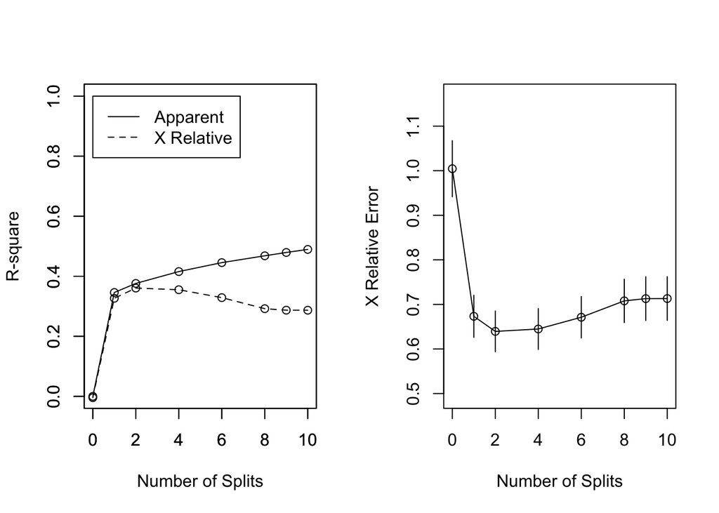

```r
par(mfrow=c(1,2)) # two plots on one page
rsq.rpart(fit) # visualize cross-validation results
```

2. Attempt both a bagging and boosting method on a reasonable dataset of your choice. Explain the results.

```r
# I'm using a different function and slightly different method for bagging than what was shown in class.
# I'm using the bagging function from the 'ipred' package to do bagging on the dataset. The first argument in the function is what and i'm predicting with what variables (pregnant with all variables). Using the training data from the above step. nbagg=100 means i'm doing a bagging regression tree with 100 bootstrap replications (100 iterations of bagged model). coob=TRUE means it will be computing the out-of-bag error rate.
# Can use the OOB observations to estimate the model’s accuracy, creating a natural cross-validation process.

set.seed(31)
training_size <- floor(0.75 * nrow(PimaIndiansDiabetes))
training_pos <- sample(seq_len(nrow(PimaIndiansDiabetes)), size = training_size)

training_data <- PimaIndiansDiabetes[training_pos, ]
testing_data <- PimaIndiansDiabetes[-training_pos, ]
#dim(training_data)
#dim(testing_data)

set.seed(31)
pima_bagging <- bagging(pregnant~., data=training_data, coob=TRUE)
pima_bagging
```

```
##
## Bagging regression trees with 25 bootstrap replications
##
## Call: bagging.data.frame(formula = pregnant ~ ., data = training_data,
##     coob = TRUE)
##
## Out-of-bag estimate of root mean squared error:  2.6407
```

```r
summary(pima_bagging)
```

```
##        Length Class      Mode
## y      576    -none-     numeric
## X        8    data.frame list
## mtrees  25    -none-     list
## OOB      1    -none-     logical
## comb     1    -none-     logical
## err      1    -none-     numeric
## call     4    -none-     call
```

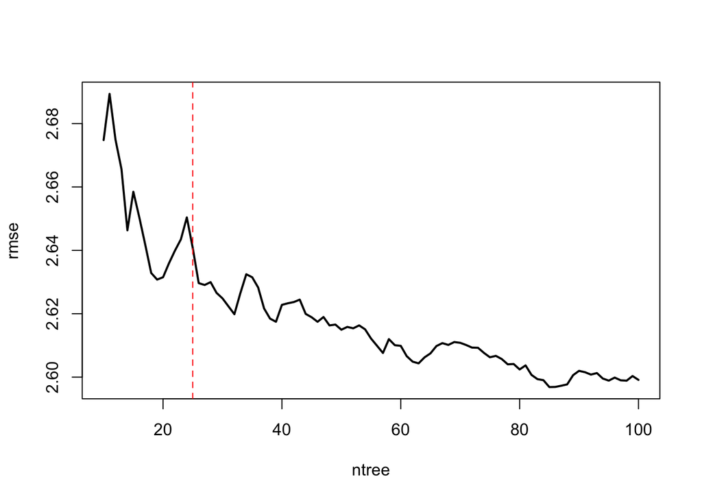

```r
# The bagging function defaults to 25 bootstrap samples. I'm going to asses the error versus the number of trees. Currently the rmse is 2.6407 with 25 bootstrap samples.
# assess 10-50 bagged trees
ntree <- 10:100

# create empty vector to store OOB RMSE values
rmse <- vector(mode = "numeric", length = length(ntree))

for (i in seq_along(ntree)) {
  # reproducibility
  set.seed(31)

  # perform bagged model
  model <- bagging(
  formula = pregnant~.,
  data    = training_data,
  coob    = TRUE,
  nbagg   = ntree[i]
)
  # get OOB error
  rmse[i] <- model$err
}

plot(ntree, rmse, type = 'l', lwd = 2)
abline(v = 25, col = "red", lty = "dashed")
```

```r
# From the plot above, it looks like the rmse can decrease a bit more with more bootstrap samples. I'm going to increase this to 100.
set.seed(31)
pima_bagging_2 <- bagging(pregnant~., data=training_data, nbagg=100, coob=TRUE)
pima_bagging_2
```

```
##
## Bagging regression trees with 100 bootstrap replications
##
## Call: bagging.data.frame(formula = pregnant ~ ., data = training_data,
##     nbagg = 100, coob = TRUE)
##
## Out-of-bag estimate of root mean squared error:  2.5991
```

```r
# predict of test set
predict_bag <- predict(pima_bagging_2, newdata=testing_data, type="class")
summary(predict_bag)
```

```
##    Min. 1st Qu.  Median    Mean 3rd Qu.    Max.
##   1.566   1.635   3.239   3.855   5.957   9.321
```

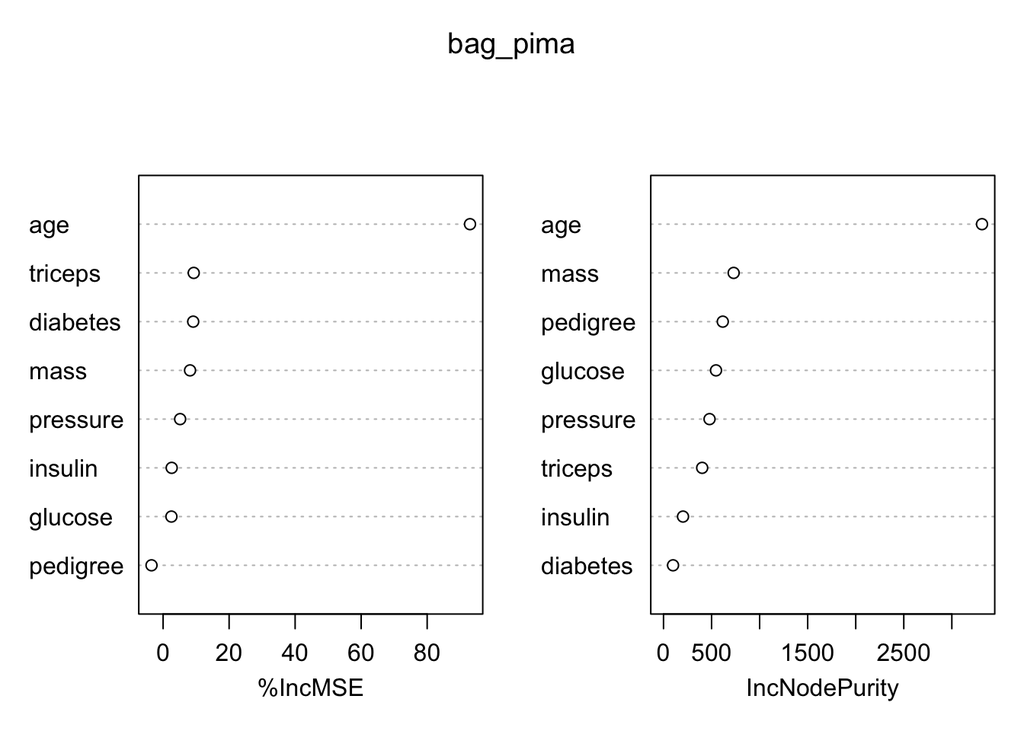

```r
# A benefit to using the randomForest function instead of the bagging function is that we can make a variable importance plot.
# Variable importance plot:
bag_pima = randomForest(pregnant~., data = training_data, mtry=8, importance=TRUE)
varImpPlot(bag_pima)
```

```r
pred_bag = predict(bag_pima, newdata = testing_data)
summary(pred_bag)
```

```
##    Min. 1st Qu.  Median    Mean 3rd Qu.    Max.
##  0.5614  1.8783  3.2699  3.9379  5.8667 10.2297
```

Using method in class for bagging with the Pima Indian Diabetes data in mlbench:

```r
## Bagging is a way to decrease the variance in prediction models using decision trees.
## Method: bootstrap by taking repeated samples from the training data set. Generate B different bootstrapped training data sets. Then train our method of the bth bootstrapped training set, and average all the predictions

set.seed(31)
training_size <- floor(0.75 * nrow(PimaIndiansDiabetes))
training_pos <- sample(seq_len(nrow(PimaIndiansDiabetes)), size = training_size)

training_data <- PimaIndiansDiabetes[training_pos, ]
testing_data <- PimaIndiansDiabetes[-training_pos, ]
#dim(training_data)
#dim(testing_data)

set.seed(31)
rf_pima <- randomForest(pregnant~., data=PimaIndiansDiabetes, subet=training_data)
summary(rf_pima)
```

```
##                 Length Class  Mode
## call              4    -none- call
## type              1    -none- character
## predicted       768    -none- numeric
## mse             500    -none- numeric
## rsq             500    -none- numeric
## oob.times       768    -none- numeric
## importance        8    -none- numeric
## importanceSD      0    -none- NULL
## localImportance   0    -none- NULL
## proximity         0    -none- NULL
## ntree             1    -none- numeric
## mtry              1    -none- numeric
## forest           11    -none- list
## coefs             0    -none- NULL
## y               768    -none- numeric
## test              0    -none- NULL
## inbag             0    -none- NULL
## terms             3    terms  call
```

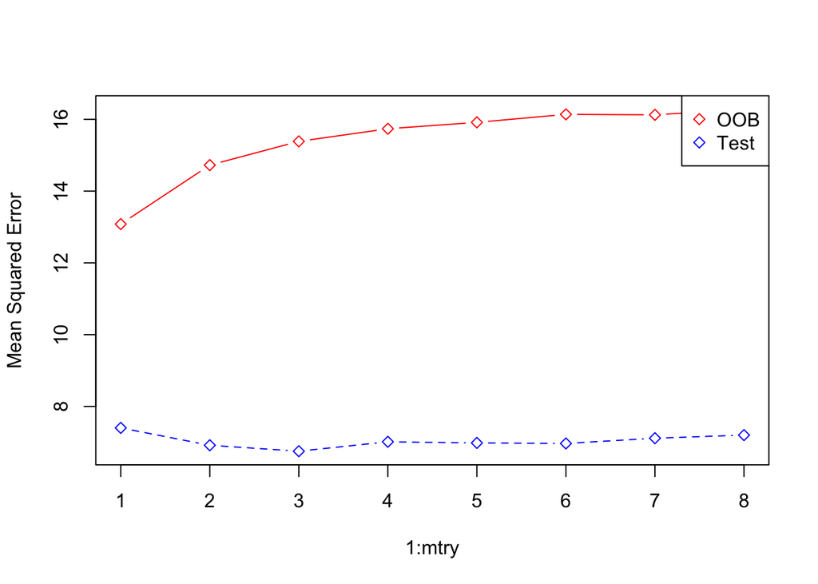

```r
#mtry=8
# iterate random forest model with 8 (mtry) different grids

set.seed(31)
# out of bag training error (MSE)
oob_error <- double(8)
# testing error (MSE)
test_error <- double(8)

# Loop of mtry from 1 to 8, fit randomForest to training dataset
for(mtry in 1:8) {
  fit_2 <- randomForest(pregnant~., data=training_data, mtry=mtry, ntree=450)
  oob_error[mtry] = fit_2$mse[450] # out-of-bag error - extract MSE
  pred_2 = predict(fit_2, new_data=testing_data,) # predict on testing data
  test_error[mtry] = with(testing_data, mean( (pregnant-pred_2)^2 )) # compute testing error
}

# Visualize the results
matplot(1:mtry, cbind(test_error, oob_error), pch = 23, col = c("red", "blue"), type = "b", ylab="Mean Squared Error")
legend("topright", legend = c("OOB", "Test"), pch = 23, col = c("red", "blue"))
```

Boosting with Pima Indian Diabetes Dataset

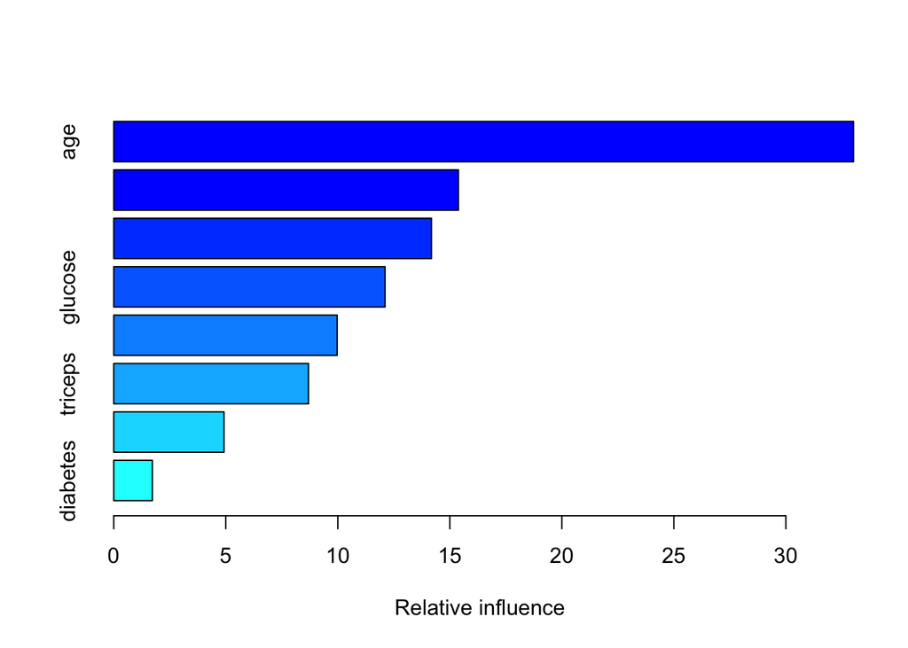

```
##               var   rel.inf
## age           age 33.018628
## pedigree pedigree 15.384682
## mass         mass 14.179332
## glucose   glucose 12.109395
## pressure pressure  9.971050
## triceps   triceps  8.692337
## insulin   insulin  4.920673
## diabetes diabetes  1.723902
```

```r
# Booting
boosting_pima = gbm(pregnant ~ ., data = train_class, distribution = "gaussian", n.trees = 10000, shrinkage = 0.01, interaction.depth = 4)

# Variable Importance Plot
summary(boosting_pima)
```

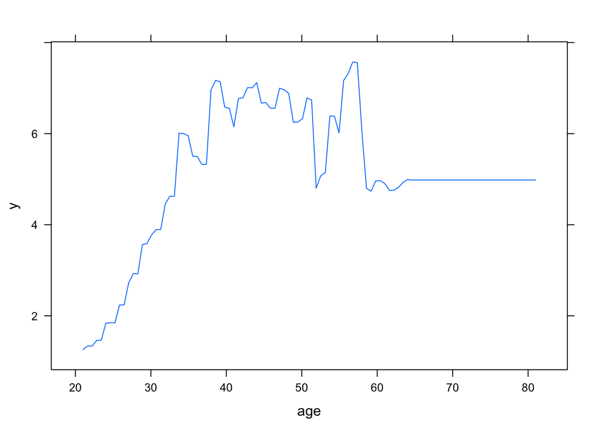

```r
# Visualize important variables of interest - from above that would be age and pedigree
plot(boosting_pima,i="age")
```

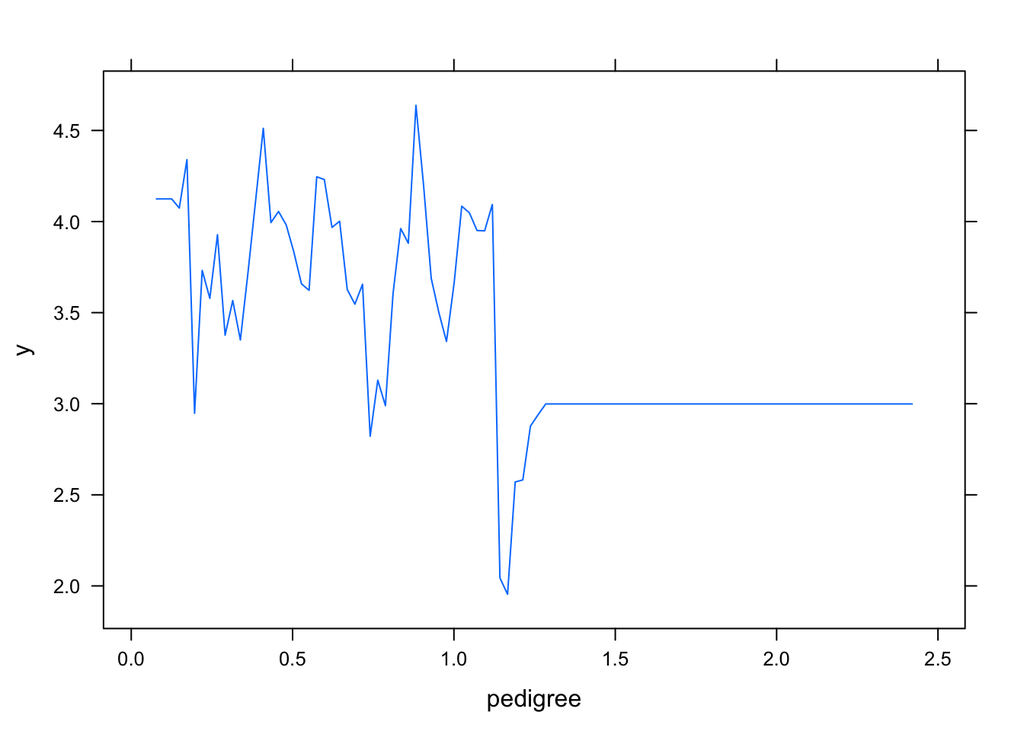

```r
plot(boosting_pima,i="pedigree")
```

```r
# Predict on test set. Number of trees - a vector of 100 values
number_trees = seq(from = 100, to = 10000, by = 100)
predmat_2 = predict(boosting_pima, newdata = test_class, n.trees = number_trees) # generate prediction matrix for each tree
dim(predmat_2) # dimensions of the prediction matrix
```

```
## [1] 192 100
```

```r
# Calculate mean squared test error
boost.err_2 = with(test_class, apply( (predmat_2 - pregnant)^2, 2, mean) )
head(boost.err_2)
```

```
##      100      200      300      400      500      600
## 7.028521 6.359266 6.255836 6.261706 6.339929 6.433353
```

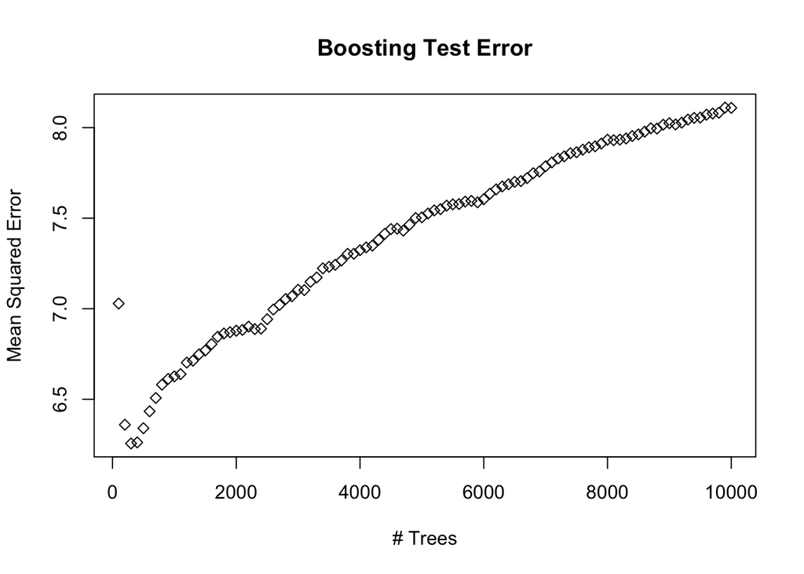

```r
# Visualize Boosting Error Plot
plot(number_trees, boost.err_2, pch = 23, ylab = "Mean Squared Error", xlab = "# Trees", main = "Boosting Test Error")
abline(h = min(test_error), col = "red")
```

Boosting is another method for reducing data with high variation and bias. From the results above, we see the most important variables for predicting the number of pregnancies in the Pima Indian Diabetes dataset are age and pedigree. From the Boosting Test Error plot, it actually looks like MSE increases as the number of trees increases. This is strange and should not be the case, because the number of trees is generally supposed to reduce the MSE. However, this could be the case because this dataset already has low variation and does not need boosting.